# Regression Analysis

In this project, we will be using **Regression backward selection** for our analysis. The label for our data will be the rating.

We need to first check to see if there’s actually a linear relationship between the feature and labels.

```r
performance <- read_csv('../data/performance.csv')
glimpse(performance)
```

```
Rows: 30
Columns: 7
$ overall_rating              <dbl> 43, 63, 71, 61, 81, 43, 58, 71, 72, 67, …
$ handles_employee_complaints <dbl> 51, 64, 70, 63, 78, 55, 67, 75, 82, 61, …
$ no_special_privileges       <dbl> 30, 51, 68, 45, 56, 49, 42, 50, 72, 45, …
$ space_for_learning          <dbl> 39, 54, 69, 47, 66, 44, 56, 55, 67, 47, …
$ raises_for_performance      <dbl> 61, 63, 76, 54, 71, 54, 66, 70, 71, 62, …
$ not_overly_critical         <dbl> 92, 73, 86, 84, 83, 49, 68, 66, 83, 80, …
$ rate_of_advancement         <dbl> 45, 47, 48, 35, 47, 34, 35, 41, 31, 41, …
```

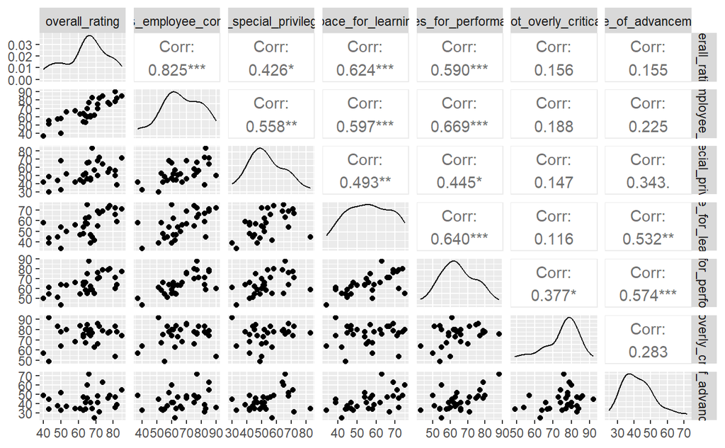

```r
## using ggpairs to check the relationships
ggpairs(performance)
```

And we do actually see some linearity in the plots with overall_rating.

We will use the t-statistic to decide which variables are not as useful for our model and can be discarded. We will keep on this process until we have a t-statistic of < 1.

```r
## for our linear model
## we have to first pass in the variable
## that we'd like our model to explain
## and then use . trick to have it use
## the rest of the columns as the input features
model <- lm(overall_rating ~ .,
            data = performance)
## and we can look at the summary of our model
summary(model)
```

```
Call:
lm(formula = overall_rating ~ ., data = performance)

Residuals:
     Min       1Q   Median       3Q      Max
-10.9418  -4.3555   0.3158   5.5425  11.5990

Coefficients:
                            Estimate Std. Error t value Pr(>|t|)
(Intercept)                 10.78708   11.58926   0.931 0.361634
handles_employee_complaints  0.61319    0.16098   3.809 0.000903 ***
no_special_privileges       -0.07305    0.13572  -0.538 0.595594
space_for_learning           0.32033    0.16852   1.901 0.069925 .
raises_for_performance       0.08173    0.22148   0.369 0.715480
not_overly_critical          0.03838    0.14700   0.261 0.796334
rate_of_advancement         -0.21706    0.17821  -1.218 0.235577
---
Signif. codes:  0 ‘***’ 0.001 ‘**’ 0.01 ‘*’ 0.05 ‘.’ 0.1 ‘ ’ 1

Residual standard error: 7.068 on 23 degrees of freedom
Multiple R-squared:  0.7326,    Adjusted R-squared:  0.6628
F-statistic:  10.5 on 6 and 23 DF,  p-value: 1.24e-05
```

Given the above summary, at the first glance we can say that given the high t-values and low probability for “handles_employee_complaints” and “space_for_learning”, these two features are the most useful ones in our model. Considering the current values, the first feature that we will remove is the “not_overly_critical”.

```r
## for our new model
## we can simply update the previous one
## the following way
## by using - not_overly_critical
## from the right side
model_1 <- update(model,
                  . ~ . - not_overly_critical)
summary(model_1)
```

```
Call:
lm(formula = overall_rating ~ handles_employee_complaints + no_special_privileges +
    space_for_learning + raises_for_performance + rate_of_advancement,
    data = performance)

Residuals:
     Min       1Q   Median       3Q      Max
-11.8088  -4.8353   0.4199   5.5775  11.5276

Coefficients:
                            Estimate Std. Error t value Pr(>|t|)
(Intercept)                 12.79791    8.49061   1.507 0.144785
handles_employee_complaints  0.61315    0.15783   3.885 0.000704 ***
no_special_privileges       -0.07224    0.13303  -0.543 0.592122
space_for_learning           0.31172    0.16202   1.924 0.066300 .
raises_for_performance       0.09795    0.20842   0.470 0.642621
rate_of_advancement         -0.21111    0.17328  -1.218 0.234956
---
Signif. codes:  0 ‘***’ 0.001 ‘**’ 0.01 ‘*’ 0.05 ‘.’ 0.1 ‘ ’ 1

Residual standard error: 6.929 on 24 degrees of freedom
Multiple R-squared:  0.7318,    Adjusted R-squared:  0.6759
F-statistic:  13.1 on 5 and 24 DF,  p-value: 3.278e-06
```

Given the updated model, now the next feature that could be removed is the “raises_for_performance”, where we have the lowest t-value.

```r
## so we will be uodating our model once again
model_2 <- update(model_1,
                  . ~ . - raises_for_performance)
summary(model_2)
```

```
Call:
lm(formula = overall_rating ~ handles_employee_complaints + no_special_privileges +
    space_for_learning + rate_of_advancement, data = performance)

Residuals:
     Min       1Q   Median       3Q      Max
-11.8976  -5.5171   0.7654   5.8086  11.5022

Coefficients:
                            Estimate Std. Error t value Pr(>|t|)
(Intercept)                 14.30347    7.73957   1.848   0.0765 .
handles_employee_complaints  0.65338    0.13051   5.006 3.67e-05 ***
no_special_privileges       -0.07682    0.13059  -0.588   0.5616
space_for_learning           0.32395    0.15741   2.058   0.0502 .
rate_of_advancement         -0.17151    0.14904  -1.151   0.2607
---
Signif. codes:  0 ‘***’ 0.001 ‘**’ 0.01 ‘*’ 0.05 ‘.’ 0.1 ‘ ’ 1

Residual standard error: 6.821 on 25 degrees of freedom
Multiple R-squared:  0.7293,    Adjusted R-squared:  0.686
F-statistic: 16.84 on 4 and 25 DF,  p-value: 8.134e-07
```

The next feature that can be removed is the “no_special_privileges”, which has the lowest absolute t-value in our remaining features.

```r
model_3 <- update(model_2,
                  . ~ . - no_special_privileges)
summary(model_3)
```

```
Call:
lm(formula = overall_rating ~ handles_employee_complaints + space_for_learning +
    rate_of_advancement, data = performance)

Residuals:
    Min      1Q  Median      3Q     Max
-12.217  -5.377   0.967   6.078  11.540

Coefficients:
                            Estimate Std. Error t value Pr(>|t|)
(Intercept)                  13.5777     7.5439   1.800   0.0835 .
handles_employee_complaints   0.6227     0.1181   5.271 1.65e-05 ***
space_for_learning            0.3124     0.1542   2.026   0.0532 .
rate_of_advancement          -0.1870     0.1449  -1.291   0.2082
---
Signif. codes:  0 ‘***’ 0.001 ‘**’ 0.01 ‘*’ 0.05 ‘.’ 0.1 ‘ ’ 1

Residual standard error: 6.734 on 26 degrees of freedom
Multiple R-squared:  0.7256,    Adjusted R-squared:  0.6939
F-statistic: 22.92 on 3 and 26 DF,  p-value: 1.807e-07
```

Now, all of absolute t-values are above 1, and we can stop removing features at this point. The probability of getting the same results even after removing “rate_of_advancement” is still very high, but in order to avoid over-fitting, we will keep that feature for any future data that we might want to analyze.

We will move forward to create our residual plot, using the broom package.

```r
## first creating an augmented set
## using our last model
performance_aug <- augment(model_3)
glimpse(performance_aug)
```

```
Rows: 30
Columns: 10
$ overall_rating              <dbl> 43, 63, 71, 61, 81, 43, 58, 71, 72, 67, 64, 67, 69, 68, 77, 81,…
$ handles_employee_complaints <dbl> 51, 64, 70, 63, 78, 55, 67, 75, 82, 61, 53, 60, 62, 83, 77, 90,…
$ space_for_learning          <dbl> 39, 54, 69, 47, 66, 44, 56, 55, 67, 47, 58, 39, 42, 45, 72, 72,…
$ rate_of_advancement         <dbl> 45, 47, 48, 35, 47, 34, 35, 41, 31, 41, 34, 41, 25, 35, 46, 36,…
$ .fitted                     <dbl> 49.10726, 61.51465, 69.74989, 60.94862, 73.98151, 55.21658, 66.…
$ .resid                      <dbl> -6.10726377, 1.48534649, 1.25011415, 0.05137535, 7.01848630, -1…
$ .hat                        <dbl> 0.15711669, 0.04687593, 0.08220093, 0.06249151, 0.06375935, 0.0…
$ .sigma                      <dbl> 6.737530, 6.860887, 6.862671, 6.867624, 6.712661, 6.377441, 6.6…
$ .cooksd                     <dbl> 4.547159e-02, 6.275755e-04, 8.406984e-04, 1.034521e-06, 1.97521…
$ .std.resid                  <dbl> -0.987808189, 0.225924186, 0.193769552, 0.007879104, 1.07710831…
```

And then plotting our predictions as well as the residuals to make sure there’s no specific pattern in the distribution of the residuals, which will show that the linear model is working as expected.

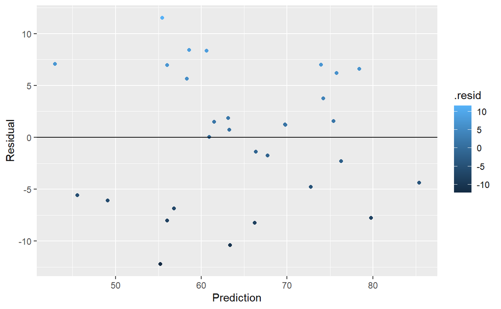

```r
## the residual plot using ggplot scatter
ggplot(performance_aug, aes(x = .fitted, y = .resid, color=.resid)) +
  geom_point() +
  labs(x='Prediction', y='Residual') +
  geom_hline(yintercept = 0)
```

The last step is to compare the AIC for our models, and it’s a better measure compared to $r^2$, primarily, because it gets worse by adding additional features that don’t improve the model and are mainly noise, as opposed to the $r^2$, which improves with additional features, regardless of their true value.

```r
## first making a listof all models
model_list <- list(model, model_1,
                   model_2, model_3)
## and then apply the AIC
lapply(model_list, extractAIC)
```

```
[[1]]
[1]   7.0000 123.3635

[[2]]
[1]   6.0000 121.4523

[[3]]
[1]   5.0000 119.7271

[[4]]
[1]   4.0000 118.1395
```

As we can see, the AIC is going down with each iteration, which shows improvement in the performance of our model, even though we’re removing data.